# Gen Scotland: epigenetic clocks / cell composition PCs and health outcomes

21 July, 2026

In this script, the results of Scripts 1-4 will be analysed, and several figures will be made to show whether epigenetic clocks and/or cell composition PCs associate with health outcomes:

- The correlations of the cell composition PCs with the individual cell counts from which they were constructed. These should be comparable to the correlations observed in the manuscript.
- A series of boxplots showing the -log10(p-value) of the effect of cell composition on disease hazard. This only shows the global effect of cell composition, and gives no information about individual cell comoposition PCs. Here, we find that 12 health outcomes are affected by cell composition, including all-cause mortality. We will continue with these 12 diseases in further figures.
- A heatmap showing the Z-score of all cell composition PCs, including significance stars, as a metric of their effect on each of the 12 health outcomes. This shows which PCs are associated with each disease.
- A scatterplot of the effect of epigenetic clocks on health outcomes, before and after adjustment for cell composition PCs. This shows whether the epigenetic clocks’ associations with health outcomes is dependent on cell composition or not.

#Setup

Load results.

```r
setwd("/exports/molepi/RSC_BIOS/Users/tjonkman/cellcounts/test/FORK_Epigenetic_Clocks_and_Disease_GS")
.libPaths("/exports/molepi/RSC_BIOS/Users/tjonkman/Packages/4.3.1")

#Load mortality results.
load("/exports/molepi/RSC_BIOS/Users/tjonkman/cellcounts/test/FORK_Epigenetic_Clocks_and_Disease_GS/Mortality_results_2.rda")
m <- all_results

#Load disease results.
load("/exports/molepi/RSC_BIOS/Users/tjonkman/cellcounts/test/FORK_Epigenetic_Clocks_and_Disease_GS/Disease_Results_2.rda")
d <- all_results
```

Merge mortality and disease results. Keep the clock results (including clock+PC-adjustment) and the PC results separate.

```r
#Separate disease results into clocks (dc) and cell composition PCs (dp).
dc <- d[grep("clocks", d$model), c("Clock", "disease", "HR", "LCI", "UCI", "Z", "P", "model")]

dp <- d[-grep("clocks", d$model), ]
dp <- dp[dp$Clock == "Hannum",]
dp <- dp[, c("disease", "HR", "LCI", "UCI", "Z", "P", "model")]
dp$model <- gsub(pattern = "pc", replacement = "PC", x = dp$model)

#Separate mortality results into clocks (dc) and cell composition PCs (dp).
mc <- do.call("rbind", m[1:12])
mc$disease <- "mortality"
mc$model <- paste0("clocks", c(rep("", 6), rep(".pc1", 6), rep(".pc1.2", 6), rep(".pc1.3", 6), rep(".pc1.4", 6), rep(".pc1.5", 6), rep(".pc1.6", 6), rep(".pc1.7", 6), rep(".pc1.8", 6), rep(".pc1.9", 6), rep(".pc1.10", 6), rep(".pc1.11", 6)))
mc <- mc[, c("Clock", "disease", "HR", "LCI", "UCI", "Z", "P", "model")]
mp <- m[[13]]

mp$disease <- "mortality"
mp$model <- mp$PC
mp <- mp[, c("disease", "HR", "LCI", "UCI", "Z", "P", "model")]

head(dc) #disease effects of clocks and clocks+cell composition PCs.
```

```
##           Clock           disease        HR       LCI      UCI          Z
## 1 DNAmGrimAge.1              acne 0.8225399 0.6190735 1.092878 -1.3474259
## 2 DNAmGrimAge.1 actinic_keratosis 0.9463308 0.7676417 1.166615 -0.5166537
## 3 DNAmGrimAge.1                AF 1.2486611 1.1414221 1.365975  4.8471705
## 4 DNAmGrimAge.1   agranulocytosis 1.3049100 1.0386073 1.639494  2.2852793
## 5 DNAmGrimAge.1               AKI 1.5348907 1.3890061 1.696097  8.4086688
## 6 DNAmGrimAge.1      alc_problems 1.2542437 1.1524957 1.364974  5.2480939
##              P  model
## 1 1.778431e-01 clocks
## 2 6.053979e-01 clocks
## 3 1.252348e-06 clocks
## 4 2.229645e-02 clocks
## 5 4.146904e-17 clocks
## 6 1.536810e-07 clocks
```

```r
head(mc) #mortality effects of clocks and clocks+cell composition PCs.
```

```
##                  Clock   disease       HR      LCI      UCI         Z
## clocks.1 DNAmGrimAge.1 mortality 1.570645 1.492308 1.653094 17.296188
## clocks.2   DunedinPACE mortality 1.455841 1.362263 1.555848 11.080360
## clocks.3        Hannum mortality 1.168106 1.113196 1.225725  6.325241
## clocks.4     Horvathv1 mortality 1.133640 1.075097 1.195370  4.636725
## clocks.5      PhenoAge mortality 1.317418 1.252605 1.385585 10.710303
## clocks.6     Zhang_Acc mortality 1.067199 1.005846 1.132294  2.152947
##                     P  model
## clocks.1 5.025609e-67 clocks
## clocks.2 1.562431e-28 clocks
## clocks.3 2.528380e-10 clocks
## clocks.4 3.539721e-06 clocks
## clocks.5 9.106294e-27 clocks
## clocks.6 3.132285e-02 clocks
```

```r
head(dp) #disease effects of composition PCs alone.
```

```
##                 disease        HR       LCI       UCI          Z           P
## 12951              acne 0.9236679 0.7843477 1.0877350 -0.9518594 0.341168287
## 12952 actinic_keratosis 0.9559569 0.8352609 1.0940934 -0.6541024 0.513045835
## 12953                AF 1.0643862 0.9913709 1.1427791  1.7209726 0.085255797
## 12954   agranulocytosis 0.8124327 0.7327072 0.9008331 -3.9417923 0.000080875
## 12955               AKI 1.1067049 1.0025395 1.2216931  2.0102900 0.044400506
## 12956      alc_problems 1.0554576 0.9875925 1.1279861  1.5917937 0.111431070
##       model
## 12951   PC1
## 12952   PC1
## 12953   PC1
## 12954   PC1
## 12955   PC1
## 12956   PC1
```

```r
head(mp) #mortality effects of composition PCs alone.
```

```
##     disease        HR       LCI       UCI          Z           P model
## 1 mortality 1.0843684 1.0284907 1.1432820  3.0007472 0.002693181   PC1
## 2 mortality 0.9409963 0.8836279 1.0020893 -1.8949668 0.058096795   PC2
## 3 mortality 1.1272775 1.0602583 1.1985330  3.8310935 0.000127575   PC3
## 4 mortality 0.9298343 0.8735374 0.9897594 -2.2830305 0.022428570   PC4
## 5 mortality 0.9900803 0.9362649 1.0469891 -0.3496231 0.726621600   PC5
## 6 mortality 0.9826379 0.9068728 1.0647328 -0.4278329 0.668772816   PC6
```

```r
#Add disease group annotation.
dis.info <- read.csv("combined_disease_names_and_groups.csv", header = T)
rownames(dis.info) <- dis.info$name
head(dis.info)
```

```
##                                   phenotype              name
## AAA               Abdominal aortic aneurysm               AAA
## hernia_abdo                Abdominal Hernia       hernia_abdo
## acne                                   Acne              acne
## actinic_keratosis         Actinic keratosis actinic_keratosis
## AKI                     Acute Kidney Injury               AKI
## agranulocytosis             Agranulocytosis   agranulocytosis
##                                             Group
## AAA                                Cardiovascular
## hernia_abdo                             Digestive
## acne                                         Skin
## actinic_keratosis                             Eye
## AKI                                 Genitourinary
## agranulocytosis   Haematological or immunological
```

```r
#Merge clock results.
d <- as.data.frame(rbind(mc, dc))
d$Clock <- factor(d$Clock, levels = c("Hannum", "Horvathv1", "Zhang_Acc", "PhenoAge", "DNAmGrimAge.1", "DunedinPACE"))
levels(d$Clock) <- c("Hannum", "Horvath", "Zhang", "PhenoAge", "GrimAge", "DunedinPACE")
d$group <- dis.info$Group[match(d$disease, dis.info$name)]
d$group[d$disease == "mortality"] <- "Mortality"
# d$group <- factor(d$group, levels = unique(d$group))
d$group <- factor(d$group, levels = c("Mortality", "Cardiovascular", "Endocrine", "Digestive", "Benign neoplasm or Carcinoma in situ", "Cancers", "Haematological or immunological", "Infections", "Musculoskeletal", "Neurological", "Psychiatric", "Respiratory", "Skin", "Genitourinary", "Eye", "Ear"))
levels(d$group)[c(5,7)] <- c("Benign neoplasms/CIS", "Haematological")
d <- d[order(d$group, d$Clock),]
d$disease <- factor(d$disease, levels = unique(d$disease))
d$model <- factor(d$model, levels = unique(d$model))
d <- d[order(d$group, d$Clock, d$disease, d$model),]
head(d)
```

```
##                 Clock   disease       HR      LCI      UCI        Z
## clocks.3       Hannum mortality 1.168106 1.113196 1.225725 6.325241
## clocks.pc1.3   Hannum mortality 1.159595 1.103666 1.218358 5.870891
## clocks.pc1.2.3 Hannum mortality 1.154919 1.098188 1.214580 5.604694
## clocks.pc1.3.3 Hannum mortality 1.144152 1.087555 1.203696 5.202630
## clocks.pc1.4.3 Hannum mortality 1.147828 1.090568 1.208095 5.280703
## clocks.pc1.5.3 Hannum mortality 1.148271 1.090258 1.209371 5.227004
##                           P        model     group
## clocks.3       2.528380e-10       clocks Mortality
## clocks.pc1.3   4.334584e-09   clocks.pc1 Mortality
## clocks.pc1.2.3 2.086229e-08 clocks.pc1.2 Mortality
## clocks.pc1.3.3 1.964874e-07 clocks.pc1.3 Mortality
## clocks.pc1.4.3 1.286891e-07 clocks.pc1.4 Mortality
## clocks.pc1.5.3 1.722791e-07 clocks.pc1.5 Mortality
```

```r
#Merge PC results.
d2 <- as.data.frame(rbind(mp, dp))
d2$group <- dis.info$Group[match(d2$disease, dis.info$name)]
d2$group[d2$disease == "mortality"] <- "Mortality"
# d2$group <- factor(d2$group, levels = unique(d2$group))
d2$group <- factor(d2$group, levels = c("Mortality", "Cardiovascular", "Endocrine", "Digestive", "Benign neoplasm or Carcinoma in situ", "Cancers", "Haematological or immunological", "Infections", "Musculoskeletal", "Neurological", "Psychiatric", "Respiratory", "Skin", "Genitourinary", "Eye", "Ear"))
levels(d2$group)[c(5,7)] <- c("Benign neoplasms/CIS", "Haematological")

d2 <- d2[order(d2$group),]
d2$disease <- factor(d2$disease, levels = unique(d2$disease))
d2$model <- factor(d2$model, levels = unique(d2$model))

d2$PC <- d2$model
pc.labs <- c("PC1: Neutrophils", "PC2: T cell naive/memory", "PC3: Treg/CD4Tmem", "PC4: Bmem/Mono", "PC5: Bnv/Eos", "PC6: Naive CD8 T cells", "PC7: Mixed (CD4Tnv/CD8Tnv)", "PC8: Eos/Mono", "PC9: Mixed (CD4Tnv+CD8Tmem)", "PC10: Mixed (Bmem)", "PC11: Mixed (Baso)")
levels(d2$PC) <- pc.labs

d2 <- d2[order(d2$group, d2$disease, d2$model),]
head(d2)
```

```
##     disease        HR       LCI       UCI          Z           P model
## 1 mortality 1.0843684 1.0284907 1.1432820  3.0007472 0.002693181   PC1
## 2 mortality 0.9409963 0.8836279 1.0020893 -1.8949668 0.058096795   PC2
## 3 mortality 1.1272775 1.0602583 1.1985330  3.8310935 0.000127575   PC3
## 4 mortality 0.9298343 0.8735374 0.9897594 -2.2830305 0.022428570   PC4
## 5 mortality 0.9900803 0.9362649 1.0469891 -0.3496231 0.726621600   PC5
## 6 mortality 0.9826379 0.9068728 1.0647328 -0.4278329 0.668772816   PC6
##       group                       PC
## 1 Mortality         PC1: Neutrophils
## 2 Mortality PC2: T cell naive/memory
## 3 Mortality        PC3: Treg/CD4Tmem
## 4 Mortality           PC4: Bmem/Mono
## 5 Mortality             PC5: Bnv/Eos
## 6 Mortality   PC6: Naive CD8 T cells
```

As a sanity check, plot the correlations between cell composition PCs and individual cell counts, to ensure these look similar to our own cohort.

```r
corr.pcs <- readRDS("/exports/molepi/RSC_BIOS/Users/tjonkman/cellcounts/test/FORK_Epigenetic_Clocks_and_Disease_GS/WBC_PC_correlations_2.RDS")
celltypes <- c("Neutrophils", "Eosinophils", "Basophils", "Monocytes", "Naive B cells", "Memory B cells", "Naive CD4 T cells", "Memory CD4 T cells", "Naive CD8 T cells", "Memory CD8 T cells", "Regulatory T cells", "Natural Killer cells")
rownames(corr.pcs) <- celltypes
head(corr.pcs)
```

```
##                       PC1         PC2         PC3         PC4         PC5
## Neutrophils     0.8968473 -0.01099167  0.25028325 -0.14536604 -0.06246144
## Eosinophils    -0.5569403 -0.04503434 -0.02273199 -0.13061753 -0.70926014
## Basophils      -0.3648308 -0.03107789  0.30973912 -0.09483667 -0.31023801
## Monocytes      -0.2064439 -0.24015120 -0.23268780 -0.46217455 -0.26567299
## Naive B cells  -0.4293248  0.35960269 -0.32644339 -0.07412551  0.54703635
## Memory B cells -0.4037751 -0.23173974  0.22109082  0.78808864 -0.08070047
##                        PC6         PC7         PC8         PC9        PC10
## Neutrophils     0.10373303  0.04445521 -0.18117372 -0.25690304 -0.13891831
## Eosinophils    -0.30030411 -0.69316241  0.81293252  0.28438036  0.12289574
## Basophils      -0.38309695 -0.19698846  0.05175796 -0.14332147 -0.20627714
## Monocytes      -0.04999363 -0.09481488 -0.24193373  0.07295811 -0.04452639
## Naive B cells  -0.59917382 -0.19894226  0.04875657 -0.16301028  0.40268908
## Memory B cells  0.23296563 -0.01564803 -0.40756223 -0.38159298  0.71756885
##                       PC11       PC12
## Neutrophils     0.39144162  0.5575013
## Eosinophils     0.04593128 -0.2731771
## Basophils       0.56653805 -0.1014019
## Monocytes      -0.07946294 -0.1035227
## Naive B cells  -0.08560380 -0.2390047
## Memory B cells  0.13033240 -0.2716757
```

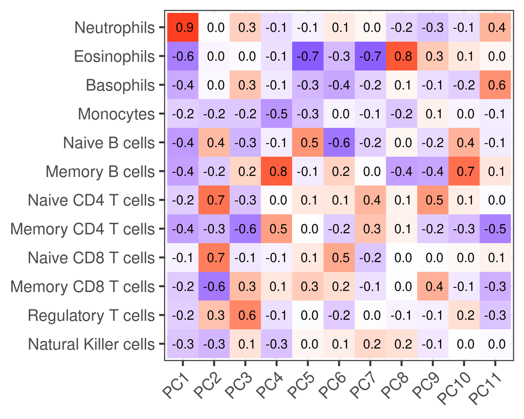

```r
library(reshape2)
library(ggplot2)
library(ggpubr)
plot.theme <- list(
  geom_point(shape = 1),
  geom_smooth(method = "lm"),
  stat_cor(method = "pearson", cor.coef.name = "R", label.x = -Inf, label.y = 105, hjust = 0, vjust = 0.7, size = 3.5, r.digits = 1, label.sep = ",  "),
  facet_wrap(facets = vars(cell.type)),
  theme_bw(),
  theme(strip.text = element_text(size = 10)),
  scale_y_continuous(limits = c(-10, 105), breaks = seq(-25, 100, 25))
)

#Correlations between PCs and cell counts.
corr.pcs <- t(corr.pcs)[1:11,]

corr.pcs <- melt(corr.pcs, varnames = c("PC", "cell.type"), value.name = "Correlation")
corr.pcs$cell.type <- factor(corr.pcs$cell.type, levels = rev(levels(corr.pcs$cell.type)))

ggplot(corr.pcs, aes(x = PC, y = cell.type, fill = Correlation)) +
  geom_tile() +
  geom_text(aes(label = format(round(Correlation, 1), digits = 1)), vjust = 0.5, hjust = 0.5, size = 2.5) +
  scale_fill_gradient2(low = "blue", mid = "white", high = "red",
                       midpoint = 0, limit = c(-1, 1)) +
  labs(x = NULL, y = NULL) +
  theme_bw() +
  theme(axis.text.x = element_text(angle = 45, hjust = 1)) +
  guides(fill = "none")
```

#Plot results

Inspect mortality results of PCs alone.

```r
m$an.raw[1] #The evidence that cell counts predict mortality. NB: not dependent on clock, so only the first clock is shown.
```

```
## $Hannum
## [1] 2.306037e-11
```

```r
m$an.clocks #The evidence that addition of cell counts improves the mortality prediction of the model. Significant for all clocks, especially cc-independent clocks (horvath and zhang).
```

```
## $Hannum
## [1] 4.761224e-08
##
## $Horvathv1
## [1] 6.662178e-11
##
## $Zhang_Acc
## [1] 5.304132e-11
##
## $PhenoAge
## [1] 1.041659e-05
##
## $DNAmGrimAge.1
## [1] 0.0006576246
##
## $DunedinPACE
## [1] 2.871662e-06
```

Inspect disease results

```r
#Load the evidence of a cell count effect for each clock.
load("/exports/molepi/RSC_BIOS/Users/tjonkman/cellcounts/test/FORK_Epigenetic_Clocks_and_Disease_GS/WBC_LRT_2.rda")

#Select only one clock; the results are identical for each clock.
res.an <- res.an$Hannum

#Create a full list of outcomes that are bonferroni-significantly celltype-dependent for at least 1 disease.
x <- as.data.frame(do.call("rbind", res.an))
disease.list <- rownames(x)[which(x$V1 < 0.05/175)]
full.list <- c("mortality", disease.list)
full.list #12 outcomes
```

```
##  [1] "mortality"     "alc_problems"  "asthma"        "cirrhosis"
##  [5] "coeliac"       "COPD"          "liver_alc"     "nasal_polyp"
##  [9] "NHL"           "oth_anaemia"   "oth_organisms" "thyroid"
```

Make boxplots for the LRT p-values. This will show, per health outcome, the level of evidence that cell composition is predictive of the outcome’s hazard. 176 outcomes will be tested, and outcomes that have a Bonferroni-significant association will be labeled.

```r
l <- as.data.frame(do.call("cbind", res.an))
l$mortality <- m$an.raw$Hannum
l <- as.data.frame(t(l))
colnames(l) <- "p"
l$disease <- rownames(l)
l$group <- d2$group[match(l$disease, d2$disease)]
l$p <- -log10(l$p)
head(l)
```

```
##                            p           disease          group
## acne              0.09441686              acne           Skin
## actinic_keratosis 0.13402723 actinic_keratosis            Eye
## AF                2.57441909                AF Cardiovascular
## agranulocytosis   2.69597339   agranulocytosis Haematological
## AKI               3.19643361               AKI  Genitourinary
## alc_problems      6.55109894      alc_problems    Psychiatric
```

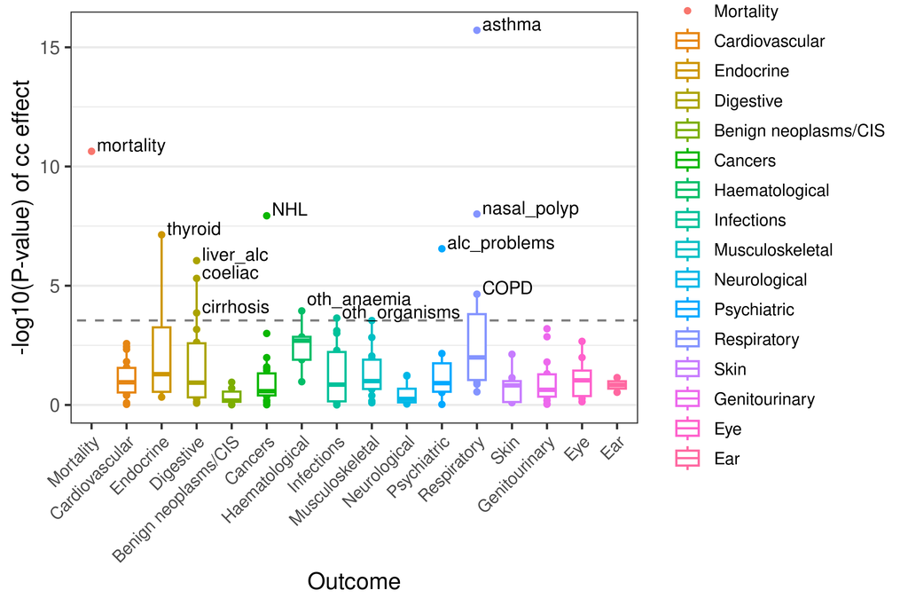

```r
threshold <- -log10(0.05/175)
l2 <- subset(l, p > threshold)

ggplot(l, aes(x = group, y = p, color = group)) +
  geom_abline(intercept = threshold, slope = 0, linetype = "dashed", alpha = 0.5) +
  geom_point(size = 1) +
  geom_boxplot(data = subset(l, group != "Mortality"), width = 0.5, outliers = F) +
  geom_text(
    data = l2,
    aes(label = disease),
    hjust = 0,
    vjust = 0,
    size = 3,
    color = "black",
    show.legend = FALSE,
    nudge_x = 0.15, nudge_y = c(0, 0, 0, 0, 0, 0, 0, 0, 0.25, 0, 0, 0)
  ) +
  theme_bw() +
  theme(axis.text.x = element_text(size = 8, angle = 45, hjust = 1),
        panel.grid.major.x = element_blank(),
        legend.key.size = unit(0.5, "cm"),
        legend.text = element_text(size = 8)) +
  labs(x = "Outcome", y = "-log10(P-value) of cc effect")
```

Make a heatmap of the Z-scores per PC-outcome association for the 12 diseases that showed up in the boxplots above. This shows the level of evidence that each individual cell composition PC (rather than the aggregate effect of all cell counts) is predictive of the health outcome.

```r
library(reshape2)
x <- d2[d2$disease %in% full.list, ]
x$PC <- factor(x$PC, levels = rev(levels(x$PC)))
x$sig.star <- factor("", levels = c("", "*", "**", "***"))
x$sig.star[x$P < 0.01] <- "*"
x$sig.star[x$P < 0.001] <- "**"
x$sig.star[x$P < 0.0001] <- "***"
head(x)
```

```
##     disease        HR       LCI       UCI          Z           P model
## 1 mortality 1.0843684 1.0284907 1.1432820  3.0007472 0.002693181   PC1
## 2 mortality 0.9409963 0.8836279 1.0020893 -1.8949668 0.058096795   PC2
## 3 mortality 1.1272775 1.0602583 1.1985330  3.8310935 0.000127575   PC3
## 4 mortality 0.9298343 0.8735374 0.9897594 -2.2830305 0.022428570   PC4
## 5 mortality 0.9900803 0.9362649 1.0469891 -0.3496231 0.726621600   PC5
## 6 mortality 0.9826379 0.9068728 1.0647328 -0.4278329 0.668772816   PC6
##       group                       PC sig.star
## 1 Mortality         PC1: Neutrophils        *
## 2 Mortality PC2: T cell naive/memory
## 3 Mortality        PC3: Treg/CD4Tmem       **
## 4 Mortality           PC4: Bmem/Mono
## 5 Mortality             PC5: Bnv/Eos
## 6 Mortality   PC6: Naive CD8 T cells
```

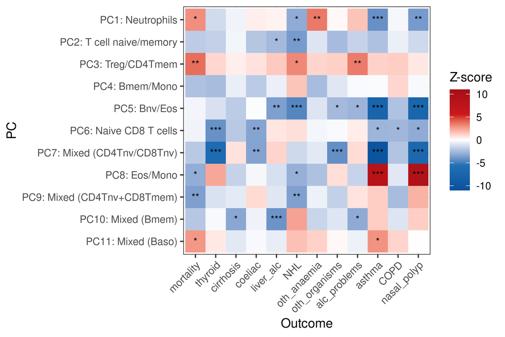

```r
ggplot(x, aes(x = disease, y = PC, fill = Z, label = sig.star)) +
  geom_tile() +
  scale_fill_gradientn(
    colors = c("#08519C", "#2171B5", "white", "#CB181D", "#A50F15"),
    limits = c(-11, 11)
  ) +
  geom_text(size = 3) +
  theme_bw() +
  theme(axis.text.x = element_text(angle = 45, hjust = 1)) +
  labs(x = "Outcome", y = "PC", fill = "Z-score")
```

Finally, make a scatterplot of the effect size of epigenetic clocks on health outcomes, before and after adjustment for cell composition PCs. This shows whether the clock effect may have been driven by underlying cell composition effects. If the line between X (unadjusted) and Y (cell composition adjusted) is not equal to X=Y, tested by ANOVA, we conclude that cell composition affects the clock’s associations with health outcomes.

```r
#Load disease information.
dis.info <- read.csv("combined_disease_names_and_groups.csv", header = T)
head(dis.info[order(dis.info$Group),])
```

```
##                                                             phenotype
## 34                                Benign neoplasm and polyp of uterus
## 35 Benign neoplasm of brain and other parts of central nervous system
## 36              Benign neoplasm of colon, rectum, anus and anal canal
## 37                                           Benign neoplasm of ovary
## 38                            Benign neoplasm of stomach and duodenum
## 42                                         Carcinoma in situ_cervical
##              name                                Group
## 34  benign_uterus Benign neoplasm or Carcinoma in situ
## 35   benign_brain Benign neoplasm or Carcinoma in situ
## 36   benign_colon Benign neoplasm or Carcinoma in situ
## 37   benign_ovary Benign neoplasm or Carcinoma in situ
## 38 benign_stomach Benign neoplasm or Carcinoma in situ
## 42   cin_cervical Benign neoplasm or Carcinoma in situ
```

```r
raw <- d[d$model == "clocks",] #Raw clock effects without PC-adjustment.
adj <- d[d$model == "clocks.pc1.11",] #PC-adjusted effects.

#Merged outcome data.
outc <- data.frame(
  clock = raw$Clock,
  outcome = raw$disease,
  raw = raw$HR,
  adj = adj$HR,
  diff = adj$HR - raw$HR
)
outc$group <- dis.info[match(outc$outcome, dis.info$name),"Group"]
outc$group[outc$outcome == "mortality"] <- "Mortality"
outc$clock = factor(outc$clock, levels = c("Hannum", "Horvath", "Zhang", "PhenoAge", "GrimAge", "DunedinPACE"))
outc$outcome <- factor(outc$outcome, levels = unique(outc$outcome))

#Re-order data based on outcome group.
outc$group <- factor(outc$group, levels = c("Mortality", "Cardiovascular", "Endocrine", "Digestive", "Benign neoplasm or Carcinoma in situ", "Cancers", "Haematological or immunological", "Infections", "Musculoskeletal", "Neurological", "Psychiatric", "Respiratory", "Skin", "Genitourinary", "Eye", "Ear"))
levels(outc$group)[c(5,7)] <- c("Benign neoplasms/CIS", "Haematological")
outc <- outc[order(outc$group),]
outc$outcome <- factor(outc$outcome, levels = unique(outc$outcome))

#Define some interesting diseases whose names to plot on top of the scatterplot.
lab.data <- subset(outc, outc$outcome %in% rownames(l2))
lab.data$hjust <- ifelse(lab.data$raw < 1, 1, 0)
head(lab.data)
```

```
##         clock   outcome      raw      adj         diff     group hjust
## 1      Hannum mortality 1.168106 1.121169 -0.046936503 Mortality     0
## 2     Horvath mortality 1.133640 1.125130 -0.008509561 Mortality     0
## 3       Zhang mortality 1.067199 1.050309 -0.016889960 Mortality     0
## 4    PhenoAge mortality 1.317418 1.260948 -0.056470742 Mortality     0
## 5     GrimAge mortality 1.570645 1.544135 -0.026509948 Mortality     0
## 6 DunedinPACE mortality 1.455841 1.413537 -0.042304013 Mortality     0
```

```r
dim(lab.data)
```

```
## [1] 72  7
```

```r
#Add data on whether the regression line between the adjusted and raw HRs is significantly different from x=y.
reg.an <- data.frame(
  clock = factor(levels(outc$clock), levels = levels(outc$clock)),
  p = NaN
)
for(i in 1:6){
  x <- outc[outc$clock == levels(outc$clock)[i],]
  reg.an$p[i] <- anova(lm(adj ~ offset(raw), data = x),
                     lm(adj ~ raw, data = x))$`Pr(>F)`[2]
}
reg.an$p.label <- ifelse(
  reg.an$p < 1e-3,
  paste0("p: ", formatC(reg.an$p, format = "e", digits = 2)),
  paste0("p: ", formatC(reg.an$p, format = "f", digits = 3))
)
reg.an
```

```
##         clock            p     p.label
## 1      Hannum 1.992050e-02    p: 0.020
## 2     Horvath 4.082813e-05 p: 4.08e-05
## 3       Zhang 1.345823e-01    p: 0.135
## 4    PhenoAge 6.238557e-04 p: 6.24e-04
## 5     GrimAge 7.222163e-01    p: 0.722
## 6 DunedinPACE 8.468915e-03    p: 0.008
```

```r
#Define x and y axis limits.
x <- c(outc$raw, outc$adj)
lims <- c(min(x), max(x))

#Plot the labeled outcomes in front.
outc2 <- outc[order(outc$outcome %in% rownames(l2)),]
head(outc2)
```

```
##     clock      outcome       raw       adj        diff          group
## 7  Hannum           AF 1.0773887 1.0406513 -0.03673742 Cardiovascular
## 8  Hannum   av_block_1 1.1221597 1.1488041  0.02664443 Cardiovascular
## 9  Hannum      CHD_NOS 0.9736162 0.9623966 -0.01121957 Cardiovascular
## 10 Hannum           hf 1.0370140 1.0055002 -0.03151381 Cardiovascular
## 11 Hannum hypertension 1.0845341 1.0680846 -0.01644954 Cardiovascular
## 12 Hannum  Isch_stroke 1.0679756 1.0119005 -0.05607513 Cardiovascular
```

```r
library(ggpmisc)
```

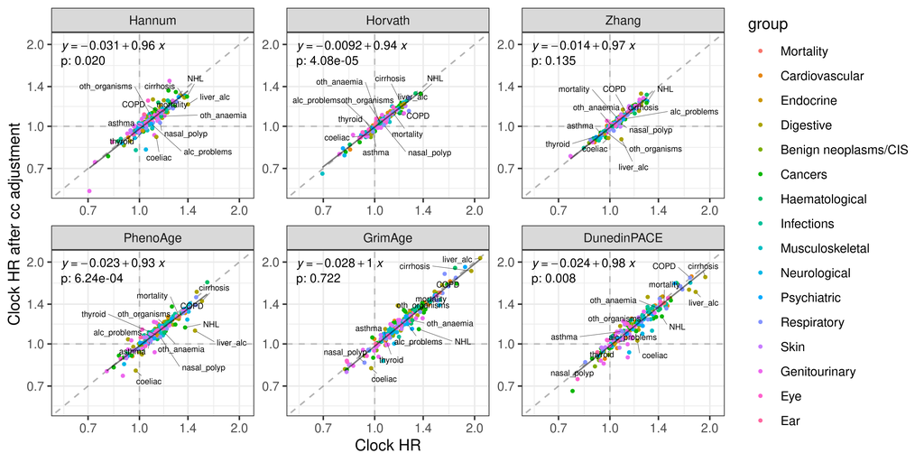

```r
library(ggrepel)
set.seed(4)
p <- ggplot(outc2, aes(x = raw, y = adj, color = group)) +
  geom_abline(intercept = 0, slope = 1, alpha = 0.3, linetype = "dashed") +
  geom_hline(yintercept = 1, alpha = 0.2, linetype = "dashed") +
  geom_vline(xintercept = 1, alpha = 0.2, linetype = "dashed") +
  geom_point(size = 0.75, alpha = 1) +
  geom_smooth(method = "lm", mapping = aes(group = 1), color = scales::alpha("black", 0.5), linewidth = 0.5, alpha = 0) +
  stat_poly_eq(aes(group = 1, label = after_stat(eq.label)), coef.digits = 2, size = 3) +
  geom_text(data = reg.an, aes(x = 0.58, y = 1.75, label = p.label), inherit.aes = FALSE, hjust = 0, size = 3) +
  geom_text_repel(
    data = lab.data,
    aes(label = outcome),
    size = 2,
    color = "black",
    show.legend = FALSE,
    max.overlaps = Inf,
    segment.size = 0.1,
    force = 5,
    box.padding = 0.3,
    min.segment.length = 0
  ) +
  facet_wrap(vars(clock), scales = "free") +
  theme_bw() +
  labs(x = "Clock HR", y = "Clock HR after cc adjustment") +
  scale_x_continuous(limits = lims, transform = "log2", breaks = c(0.5, 0.7, 1, 1.4, 2)) +
  scale_y_continuous(limits = lims, transform = "log2", breaks = c(0.5, 0.7, 1, 1.4, 2))

suppressWarnings(p)
```

We conclude that cell composition indeed has effects on several disease hazards, including all-cause mortality. Cell composition also significantly drives the association between epigenetic clocks and health outcomes, although this effect is minor.